[figure not shown]

```python
from IPython.display import Image
Image("presentación.png")
```

# Who is gonna be the winner of the next Ballon D'or 2019?

In this project the objective is to predict the player, based on his historical stat info from FIFA video games, who have more chances to win the competiton.

```python
import pandas as pd
import numpy as np
import matplotlib.pyplot as plt
%matplotlib inline
```

```python
from sklearn import linear_model
from sklearn.preprocessing import PolynomialFeatures
from sklearn.metrics import r2_score
from sklearn.metrics import mean_squared_error
```

```python
#First we call the CSV files:#
fifa_stats_2015_df=pd.read_csv("datasets/players_15.csv",usecols = [2,4,10,11,16,18,31,32,33,34,35,36])
fifa_stats_2015_df.head()
```

|  | short_name | age | overall | potential | international_reputation | skill_moves | pace | shooting | passing | dribbling | defending | physic |
| --- | --- | --- | --- | --- | --- | --- | --- | --- | --- | --- | --- | --- |
| 0 | L. Messi | 27 | 93 | 95 | 5 | 4 | 93.0 | 89.0 | 86.0 | 96.0 | 27.0 | 63.0 |
| 1 | Cristiano Ronaldo | 29 | 92 | 92 | 5 | 5 | 93.0 | 93.0 | 81.0 | 91.0 | 32.0 | 79.0 |
| 2 | A. Robben | 30 | 90 | 90 | 5 | 4 | 93.0 | 86.0 | 83.0 | 92.0 | 32.0 | 64.0 |
| 3 | Z. Ibrahimović | 32 | 90 | 90 | 5 | 4 | 76.0 | 91.0 | 81.0 | 86.0 | 34.0 | 86.0 |
| 4 | M. Neuer | 28 | 90 | 90 | 5 | 1 | NaN | NaN | NaN | NaN | NaN | NaN |

```python
#FUNCTION TO OBTAIN THE DIRECTORY OF EACH FILE
import glob
files = glob.glob('datasets/*.csv')
print(files)
```

```
['datasets/players_20.csv', 'datasets/players_18.csv', 'datasets/players_19.csv', 'datasets/players_18_BTB.csv', 'datasets/players_17.csv', 'datasets/players_16.csv', 'datasets/players_15.csv', 'datasets/teams_and_leagues.csv']
```

```python
for f in files:
   print(f)
```

```
datasets/players_20.csv
datasets/players_18.csv
datasets/players_19.csv
datasets/players_18_BTB.csv
datasets/players_17.csv
datasets/players_16.csv
datasets/players_15.csv
datasets/teams_and_leagues.csv
```

## With the datasets we made a proposal to select certain "inputs", that determine the performance of each player:

- Name (short_name)
- Age (age)
- Effectivity (overall): is the average of the key Player Attributes rates of a player within their Potential rate calculated based on their position and international reputation. The OVR rating of a player determines their general performance quality and their value in FIFA. (Score (0-100))
- Potential (potential): Player’s response to the multiple environmental interactions and stimuli that are presented day by day (Score (0-100))
- Reputation (international_reputation): (Score(1-5))
- Skills (skill_moves): Act or task that has a goal to achieve and requires voluntary body or limb movement to be properly performed(Score(1-5))
- Pace (pace): Player Attribute in FIFA that determines a player’s speed in walking and running (Score (0-100))
- Shooting (shooting): is a Player Attribute in FIFA that determines a player’s general shooting strength and accuracy (Score (0-100))
- Passing (passing): Is a Player Attribute in FIFA that determines how accurate a player passes the ball to a teammate (Score (0-100))
- Dribbling (dribbling): Is a Player Attribute in FIFA that determines a player’s ability to carry the ball and past an opponent while being in control (Score (0-100))
- Defending (defending): Is a Player Attribute in FIFA that determines a player’s ability to defend. (Score (0-100))
- Physic (physic): also knows as Physicality, is a Player Attribute in FIFA that represents the physical and body status of a player. Players with high PHY rating, are able to win the physical battles on the pitch and maintain their fitness throughout a full match (Score (0-100))

## We start cleaning the data frames, by filtering with the correspondant nominees of each year:

```python
# 2015 gold ballon finalists
finalists_2015 = ['L. Messi' , 'Cristiano Ronaldo', 'Neymar', 'R. Lewandowski', 'L. Suárez', 'T. Müller',
                 'M. Neuer', 'E. Hazard', 'Andrés Iniesta', 'A. Sánchez', 'Z. Ibrahimovic', 'Y. Touré',
                 'S. Agüero', 'J. Mascherano', 'P. Pogba', 'G. Bale', 'A. Vidal', 'K. De Bruyne',
                 'J. Rodríguez', 'K. Benzema', 'T. Kroos', 'P. Guerrero']
```

```python
finalists_2015_Df = fifa_stats_2015_df[fifa_stats_2015_df['short_name'].isin(finalists_2015)]
finalists_2015_Df=finalists_2015_Df.dropna()
finalists_2015_Df=finalists_2015_Df.loc[finalists_2015_Df['overall']>79]
finalists_2015_Df=finalists_2015_Df.reset_index(drop=True)
##finalists_2015_Df['age2']=np.power((finalists_2015_Df['age']),2)
finalists_2015_Df
```

|  | short_name | age | overall | potential | international_reputation | skill_moves | pace | shooting | passing | dribbling | defending | physic |
| --- | --- | --- | --- | --- | --- | --- | --- | --- | --- | --- | --- | --- |
| 0 | L. Messi | 27 | 93 | 95 | 5 | 4 | 93.0 | 89.0 | 86.0 | 96.0 | 27.0 | 63.0 |
| 1 | Cristiano Ronaldo | 29 | 92 | 92 | 5 | 5 | 93.0 | 93.0 | 81.0 | 91.0 | 32.0 | 79.0 |
| 2 | L. Suárez | 27 | 89 | 91 | 5 | 4 | 83.0 | 87.0 | 79.0 | 88.0 | 42.0 | 79.0 |
| 3 | E. Hazard | 23 | 88 | 90 | 4 | 4 | 90.0 | 82.0 | 84.0 | 91.0 | 32.0 | 64.0 |
| 4 | G. Bale | 24 | 87 | 91 | 4 | 4 | 94.0 | 83.0 | 83.0 | 84.0 | 63.0 | 81.0 |
| 5 | R. Lewandowski | 25 | 87 | 89 | 4 | 4 | 80.0 | 84.0 | 74.0 | 85.0 | 39.0 | 78.0 |
| 6 | J. Rodríguez | 22 | 86 | 92 | 4 | 4 | 79.0 | 80.0 | 84.0 | 85.0 | 40.0 | 72.0 |
| 7 | Neymar | 22 | 86 | 91 | 5 | 5 | 90.0 | 80.0 | 72.0 | 92.0 | 30.0 | 58.0 |
| 8 | T. Müller | 24 | 86 | 88 | 4 | 3 | 81.0 | 84.0 | 82.0 | 80.0 | 46.0 | 72.0 |
| 9 | S. Agüero | 26 | 86 | 87 | 4 | 4 | 88.0 | 86.0 | 77.0 | 88.0 | 28.0 | 66.0 |
| 10 | Y. Touré | 31 | 86 | 86 | 4 | 3 | 76.0 | 82.0 | 81.0 | 79.0 | 80.0 | 90.0 |
| 11 | T. Kroos | 24 | 85 | 88 | 4 | 3 | 58.0 | 81.0 | 89.0 | 84.0 | 58.0 | 69.0 |
| 12 | K. Benzema | 26 | 85 | 87 | 4 | 4 | 84.0 | 84.0 | 75.0 | 82.0 | 30.0 | 74.0 |
| 13 | A. Vidal | 27 | 85 | 87 | 4 | 3 | 78.0 | 78.0 | 80.0 | 81.0 | 81.0 | 83.0 |
| 14 | A. Sánchez | 25 | 84 | 88 | 3 | 4 | 88.0 | 81.0 | 75.0 | 87.0 | 39.0 | 66.0 |
| 15 | P. Pogba | 21 | 83 | 89 | 3 | 4 | 76.0 | 78.0 | 79.0 | 83.0 | 73.0 | 88.0 |
| 16 | J. Mascherano | 30 | 83 | 83 | 3 | 2 | 69.0 | 59.0 | 70.0 | 69.0 | 84.0 | 80.0 |
| 17 | K. De Bruyne | 23 | 81 | 86 | 2 | 4 | 77.0 | 80.0 | 80.0 | 82.0 | 41.0 | 69.0 |

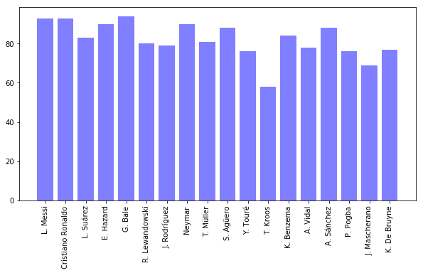

```python
x_axis = np.arange(len(finalists_2015_Df))
tick_locations = [value+0.4 for value in x_axis]
plt.figure(figsize=(10,5))
plt.bar(x_axis, finalists_2015_Df["pace"], color='b', alpha=0.5, align="edge")
plt.xticks(tick_locations, finalists_2015_Df["short_name"], rotation="vertical")
plt.show()
```

### DATA ANALYSIS

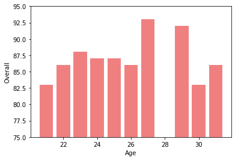

```python
plt.bar('age', 'overall', data = finalists_2015_Df, color = 'lightcoral')
plt.xlabel("Age")
plt.ylabel("Overall")
plt.ylim(75,95)
plt.show()
```

### Machine learning/Linear regression

```python
#finalists 2019
finalists_2019 = ['S. Agüero', 'T. Alexander-Arnold', 'Alisson', 'P. Aubameyang', 'K. Benzema', 'Bernardo Silva', 'Cristiano Ronaldo', 'K. De Bruyne'
'F. de Jong', 'M de Ligt','Roberto Firmino', 'A. Griezmann', 'E. Hazard', 'Joao Felix', 'K. Koulibaly', 'R. Lewandowski', 'H. Lloris', 'S. Mané', 'R. Mahrez',
'Marquinhos', 'K. Mbappe', 'L. Messi', 'M. Salah', 'H. Son', 'R. Sterling', 'D. Tadic', 'M. ter Stegen', 'D. van de Beek', 'V. van Dijk', 'G. Wijnaldum']
```

```python
finalists_2019_Df = fifa_stats_2019_df[fifa_stats_2019_df['short_name'].isin(finalists_2019)]
finalists_2019_Df=finalists_2019_Df.dropna()
finalists_2019_Df=finalists_2019_Df.loc[finalists_2019_Df['overall']>79]
finalists_2019_Df=finalists_2019_Df.reset_index(drop=True)
finalists_2019_Df
```

|  | short_name | age | overall | potential | international_reputation | skill_moves | pace | shooting | passing | dribbling | defending | physic |
| --- | --- | --- | --- | --- | --- | --- | --- | --- | --- | --- | --- | --- |
| 0 | Cristiano Ronaldo | 33 | 94 | 94 | 5 | 5 | 90.0 | 93.0 | 81.0 | 89.0 | 35.0 | 79.0 |
| 1 | L. Messi | 31 | 94 | 94 | 5 | 4 | 88.0 | 91.0 | 88.0 | 96.0 | 32.0 | 61.0 |
| 2 | E. Hazard | 27 | 91 | 91 | 4 | 4 | 91.0 | 82.0 | 86.0 | 94.0 | 35.0 | 67.0 |
| 3 | R. Lewandowski | 29 | 90 | 90 | 4 | 4 | 78.0 | 89.0 | 75.0 | 85.0 | 41.0 | 82.0 |
| 4 | A. Griezmann | 27 | 89 | 90 | 4 | 4 | 86.0 | 86.0 | 81.0 | 89.0 | 50.0 | 70.0 |
| 5 | S. Agüero | 30 | 89 | 89 | 4 | 4 | 84.0 | 89.0 | 76.0 | 89.0 | 28.0 | 73.0 |
| 6 | M. Salah | 26 | 88 | 89 | 3 | 4 | 92.0 | 84.0 | 79.0 | 89.0 | 45.0 | 72.0 |
| 7 | K. Koulibaly | 27 | 87 | 90 | 3 | 2 | 72.0 | 26.0 | 46.0 | 59.0 | 88.0 | 86.0 |
| 8 | P. Aubameyang | 29 | 87 | 87 | 3 | 4 | 94.0 | 84.0 | 75.0 | 80.0 | 37.0 | 70.0 |
| 9 | Roberto Firmino | 26 | 86 | 88 | 3 | 4 | 77.0 | 83.0 | 80.0 | 86.0 | 61.0 | 78.0 |
| 10 | S. Mané | 26 | 86 | 87 | 3 | 4 | 94.0 | 80.0 | 76.0 | 87.0 | 42.0 | 73.0 |
| 11 | R. Sterling | 23 | 85 | 88 | 3 | 4 | 93.0 | 73.0 | 76.0 | 88.0 | 47.0 | 56.0 |
| 12 | V. van Dijk | 26 | 85 | 87 | 3 | 2 | 71.0 | 60.0 | 67.0 | 70.0 | 85.0 | 84.0 |
| 13 | R. Mahrez | 27 | 85 | 85 | 3 | 5 | 85.0 | 79.0 | 81.0 | 90.0 | 37.0 | 59.0 |
| 14 | Bernardo Silva | 23 | 84 | 90 | 2 | 4 | 78.0 | 72.0 | 83.0 | 89.0 | 46.0 | 58.0 |
| 15 | Marquinhos | 24 | 84 | 89 | 3 | 2 | 75.0 | 38.0 | 69.0 | 67.0 | 85.0 | 76.0 |
| 16 | H. Son | 25 | 84 | 85 | 3 | 4 | 86.0 | 85.0 | 76.0 | 85.0 | 42.0 | 68.0 |
| 17 | K. Benzema | 30 | 84 | 84 | 4 | 4 | 76.0 | 79.0 | 76.0 | 81.0 | 32.0 | 75.0 |
| 18 | G. Wijnaldum | 27 | 82 | 83 | 3 | 4 | 76.0 | 72.0 | 77.0 | 83.0 | 72.0 | 73.0 |

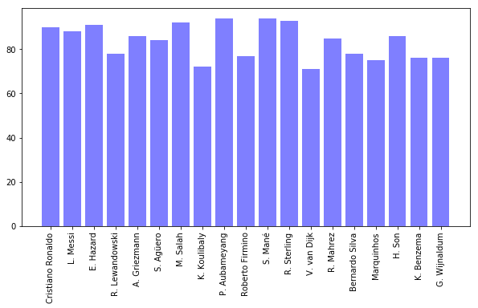

```python
x_axis = np.arange(len(finalists_2019_Df))
tick_locations = [value+0.4 for value in x_axis]
plt.figure(figsize=(10,5))
plt.bar(x_axis, finalists_2019_Df["pace"], color='b', alpha=0.5, align="edge")
plt.xticks(tick_locations, finalists_2019_Df["short_name"], rotation="vertical")
plt.show()
```

## Here we use polynomial regression for this model

```python
from sklearn import linear_model
from sklearn.preprocessing import PolynomialFeatures
from sklearn.metrics import r2_score
from sklearn.metrics import mean_squared_error
```

```python
import numpy as np
split = np.random.rand(len(finalists_2019_Df)) < 0.7
train = finalists_2019_Df[split]
test = finalists_2019_Df[~split]
print(test)
```

```
           short_name  age  overall  potential  international_reputation  \
0   Cristiano Ronaldo   33       94         94                         5
1            L. Messi   31       94         94                         5
2           E. Hazard   27       91         91                         4
4        A. Griezmann   27       89         90                         4
14     Bernardo Silva   23       84         90                         2
16             H. Son   25       84         85                         3
18       G. Wijnaldum   27       82         83                         3

    skill_moves  pace  shooting  passing  dribbling  defending  physic
0             5  90.0      93.0     81.0       89.0       35.0    79.0
1             4  88.0      91.0     88.0       96.0       32.0    61.0
2             4  91.0      82.0     86.0       94.0       35.0    67.0
4             4  86.0      86.0     81.0       89.0       50.0    70.0
14            4  78.0      72.0     83.0       89.0       46.0    58.0
16            4  86.0      85.0     76.0       85.0       42.0    68.0
18            4  76.0      72.0     77.0       83.0       72.0    73.0
```

```python
regr = linear_model.LinearRegression()
```

```python
print(train)
```

```
         short_name  age  overall  potential  international_reputation  \
3    R. Lewandowski   29       90         90                         4
5         S. Agüero   30       89         89                         4
6          M. Salah   26       88         89                         3
7      K. Koulibaly   27       87         90                         3
8     P. Aubameyang   29       87         87                         3
9   Roberto Firmino   26       86         88                         3
10          S. Mané   26       86         87                         3
11      R. Sterling   23       85         88                         3
12      V. van Dijk   26       85         87                         3
13        R. Mahrez   27       85         85                         3
15       Marquinhos   24       84         89                         3
17       K. Benzema   30       84         84                         4

    skill_moves  pace  shooting  passing  dribbling  defending  physic
3             4  78.0      89.0     75.0       85.0       41.0    82.0
5             4  84.0      89.0     76.0       89.0       28.0    73.0
6             4  92.0      84.0     79.0       89.0       45.0    72.0
7             2  72.0      26.0     46.0       59.0       88.0    86.0
8             4  94.0      84.0     75.0       80.0       37.0    70.0
9             4  77.0      83.0     80.0       86.0       61.0    78.0
10            4  94.0      80.0     76.0       87.0       42.0    73.0
11            4  93.0      73.0     76.0       88.0       47.0    56.0
12            2  71.0      60.0     67.0       70.0       85.0    84.0
13            5  85.0      79.0     81.0       90.0       37.0    59.0
15            2  75.0      38.0     69.0       67.0       85.0    76.0
17            4  76.0      79.0     76.0       81.0       32.0    75.0
```

# Testing and training model

```python
## Trainig & fitting the model
fifa_x_train = train[['potential', 'international_reputation',
       'skill_moves', 'pace', 'shooting', 'passing', 'dribbling', 'defending',
       'physic']]
fifa_y_train = train[['overall']]
poly = PolynomialFeatures(degree=4)
fifa_x_train_poly = poly.fit_transform(fifa_x_train)
regr.fit(fifa_x_train_poly, fifa_y_train)
```

```
LinearRegression(copy_X=True, fit_intercept=True, n_jobs=None,
         normalize=False)
```

```python
## Testing the model
fifa_x_test = test[['potential', 'international_reputation',
       'skill_moves', 'pace', 'shooting', 'passing', 'dribbling', 'defending',
       'physic']]
fifa_y_test = test[['overall']]
fifa_x_test_poly = poly.fit_transform(fifa_x_test)
```

```python
df_fifa_pred = regr.predict(fifa_x_test_poly)
```

```python
r2_score(fifa_y_test, df_fifa_pred)
```

```
0.9355706754351816
```

```python
fifa_x_test['Predicted Ratings'] = df_fifa_pred
```

```python
df_fifa2 = pd.merge(finalists_2019_Df,fifa_x_test)
df_fifa2.head(20)
```

|  | short_name | age | overall | potential | international_reputation | skill_moves | pace | shooting | passing | dribbling | defending | physic | Predicted Ratings |
| --- | --- | --- | --- | --- | --- | --- | --- | --- | --- | --- | --- | --- | --- |
| 0 | Cristiano Ronaldo | 33 | 94 | 94 | 5 | 5 | 90.0 | 93.0 | 81.0 | 89.0 | 35.0 | 79.0 | 94.661861 |
| 1 | L. Messi | 31 | 94 | 94 | 5 | 4 | 88.0 | 91.0 | 88.0 | 96.0 | 32.0 | 61.0 | 94.655072 |
| 2 | E. Hazard | 27 | 91 | 91 | 4 | 4 | 91.0 | 82.0 | 86.0 | 94.0 | 35.0 | 67.0 | 90.074378 |
| 3 | A. Griezmann | 27 | 89 | 90 | 4 | 4 | 86.0 | 86.0 | 81.0 | 89.0 | 50.0 | 70.0 | 88.477887 |
| 4 | Bernardo Silva | 23 | 84 | 90 | 2 | 4 | 78.0 | 72.0 | 83.0 | 89.0 | 46.0 | 58.0 | 85.811462 |
| 5 | H. Son | 25 | 84 | 85 | 3 | 4 | 86.0 | 85.0 | 76.0 | 85.0 | 42.0 | 68.0 | 85.290786 |
| 6 | G. Wijnaldum | 27 | 82 | 83 | 3 | 4 | 76.0 | 72.0 | 77.0 | 83.0 | 72.0 | 73.0 | 80.361860 |

```python
finalists_2018_Df.head(7)
```

|  | short_name | age | overall | potential | international_reputation | skill_moves | pace | shooting | passing | dribbling | defending | physic |
| --- | --- | --- | --- | --- | --- | --- | --- | --- | --- | --- | --- | --- |
| 0 | Cristiano Ronaldo | 32 | 94 | 94 | 5 | 5 | 90.0 | 93.0 | 82.0 | 90.0 | 33.0 | 80.0 |
| 1 | L. Messi | 30 | 93 | 93 | 5 | 4 | 89.0 | 90.0 | 86.0 | 96.0 | 26.0 | 61.0 |
| 2 | L. Suárez | 30 | 92 | 92 | 5 | 4 | 82.0 | 90.0 | 79.0 | 87.0 | 42.0 | 81.0 |
| 3 | E. Hazard | 26 | 90 | 91 | 4 | 4 | 90.0 | 82.0 | 84.0 | 92.0 | 32.0 | 66.0 |
| 4 | Sergio Ramos | 31 | 90 | 90 | 4 | 3 | 76.0 | 63.0 | 71.0 | 71.0 | 88.0 | 83.0 |
| 5 | K. De Bruyne | 26 | 89 | 92 | 4 | 4 | 75.0 | 84.0 | 88.0 | 85.0 | 45.0 | 75.0 |
| 6 | S. Agüero | 29 | 89 | 89 | 4 | 4 | 87.0 | 88.0 | 75.0 | 89.0 | 23.0 | 72.0 |

```python
#Now we compare the DF of 2018 to 2019

finalists_2018_Df
```

|  | short_name | age | overall | potential | international_reputation | skill_moves | pace | shooting | passing | dribbling | defending | physic |
| --- | --- | --- | --- | --- | --- | --- | --- | --- | --- | --- | --- | --- |
| 0 | Cristiano Ronaldo | 32 | 94 | 94 | 5 | 5 | 90.0 | 93.0 | 82.0 | 90.0 | 33.0 | 80.0 |
| 1 | L. Messi | 30 | 93 | 93 | 5 | 4 | 89.0 | 90.0 | 86.0 | 96.0 | 26.0 | 61.0 |
| 2 | L. Suárez | 30 | 92 | 92 | 5 | 4 | 82.0 | 90.0 | 79.0 | 87.0 | 42.0 | 81.0 |
| 3 | E. Hazard | 26 | 90 | 91 | 4 | 4 | 90.0 | 82.0 | 84.0 | 92.0 | 32.0 | 66.0 |
| 4 | Sergio Ramos | 31 | 90 | 90 | 4 | 3 | 76.0 | 63.0 | 71.0 | 71.0 | 88.0 | 83.0 |
| 5 | K. De Bruyne | 26 | 89 | 92 | 4 | 4 | 75.0 | 84.0 | 88.0 | 85.0 | 45.0 | 75.0 |
| 6 | S. Agüero | 29 | 89 | 89 | 4 | 4 | 87.0 | 88.0 | 75.0 | 89.0 | 23.0 | 72.0 |
| 7 | G. Bale | 27 | 89 | 89 | 4 | 4 | 94.0 | 87.0 | 84.0 | 86.0 | 57.0 | 76.0 |
| 8 | L. Modrić | 31 | 89 | 89 | 4 | 4 | 73.0 | 75.0 | 86.0 | 89.0 | 72.0 | 65.0 |
| 9 | A. Griezmann | 26 | 88 | 91 | 4 | 4 | 86.0 | 85.0 | 78.0 | 87.0 | 30.0 | 68.0 |
| 10 | D. Godín | 31 | 88 | 88 | 3 | 2 | 65.0 | 48.0 | 65.0 | 63.0 | 88.0 | 78.0 |
| 11 | P. Pogba | 24 | 87 | 92 | 4 | 5 | 74.0 | 79.0 | 84.0 | 85.0 | 68.0 | 88.0 |
| 12 | N. Kanté | 26 | 87 | 90 | 3 | 3 | 81.0 | 66.0 | 75.0 | 79.0 | 81.0 | 84.0 |
| 13 | I. Rakitić | 29 | 87 | 87 | 4 | 3 | 65.0 | 84.0 | 86.0 | 83.0 | 60.0 | 66.0 |
| 14 | Marcelo | 29 | 87 | 87 | 4 | 4 | 78.0 | 69.0 | 80.0 | 85.0 | 82.0 | 79.0 |
| 15 | E. Cavani | 30 | 87 | 87 | 4 | 3 | 77.0 | 83.0 | 72.0 | 80.0 | 42.0 | 81.0 |
| 16 | Isco | 25 | 86 | 90 | 3 | 4 | 71.0 | 83.0 | 82.0 | 89.0 | 54.0 | 62.0 |
| 17 | H. Kane | 23 | 86 | 90 | 3 | 3 | 71.0 | 87.0 | 72.0 | 78.0 | 42.0 | 83.0 |
| 18 | K. Benzema | 29 | 86 | 86 | 4 | 4 | 78.0 | 84.0 | 77.0 | 82.0 | 22.0 | 74.0 |
| 19 | R. Varane | 24 | 85 | 92 | 3 | 2 | 79.0 | 45.0 | 61.0 | 64.0 | 84.0 | 79.0 |
| 20 | S. Mané | 25 | 84 | 87 | 3 | 4 | 93.0 | 78.0 | 75.0 | 85.0 | 36.0 | 75.0 |
| 21 | Roberto Firmino | 25 | 83 | 87 | 3 | 4 | 77.0 | 81.0 | 79.0 | 85.0 | 46.0 | 77.0 |
| 22 | M. Salah | 25 | 83 | 86 | 3 | 4 | 93.0 | 73.0 | 74.0 | 87.0 | 45.0 | 66.0 |

```python
import numpy as np
split = np.random.rand(len(finalists_2018_Df)) < 0.875
train2 = finalists_2018_Df[split]
test2 = finalists_2018_Df[~split]
```

```python
regr2 = linear_model.LinearRegression()
```

```python
## Trainig & fitting the model
fifa_x_train2 = train2[['potential', 'international_reputation',
       'skill_moves', 'pace', 'shooting', 'passing', 'dribbling', 'defending',
       'physic']]
fifa_y_train2 = train2[['overall']]
poly = PolynomialFeatures(degree=4)
fifa_x_train_poly2 = poly.fit_transform(fifa_x_train2)
regr2.fit(fifa_x_train_poly2, fifa_y_train2)
```

```
LinearRegression(copy_X=True, fit_intercept=True, n_jobs=None,
         normalize=False)
```

```python
## Testing the model
fifa_x_test2 = test2[['potential', 'international_reputation',
       'skill_moves', 'pace', 'shooting', 'passing', 'dribbling', 'defending',
       'physic']]
fifa_y_test2 = test2[['overall']]
fifa_x_test_poly2 = poly.fit_transform(fifa_x_test2)
```

```python
df_fifa_pred2 = regr2.predict(fifa_x_test_poly2)
```

```python
r2_score(fifa_y_test2, df_fifa_pred2)
```

```
0.8289022575747265
```

```python
fifa_x_test2['Predicted Ratings'] = df_fifa_pred2
```

# And the winner for 2019 Ballon D'Or is...

[figure not shown]

```python
Image("hugo_ramos.jpeg")
```

[figure not shown]

```python
Image("LOL.png")
```

[figure not shown]

```python
Image("Messi.png")
```

```python
df_fifa9.head(20)
```

|  | short_name | age | overall | potential | international_reputation | skill_moves | pace | shooting | passing | dribbling | defending | physic | Ballon D Or Winner |
| --- | --- | --- | --- | --- | --- | --- | --- | --- | --- | --- | --- | --- | --- |
| 0 | L. Messi | 31 | 94 | 94 | 5 | 4 | 88.0 | 91.0 | 88.0 | 96.0 | 32.0 | 61.0 | 93.499421 |
| 1 | Cristiano Ronaldo | 33 | 94 | 94 | 5 | 5 | 90.0 | 93.0 | 81.0 | 89.0 | 35.0 | 79.0 | 92.406322 |
| 2 | E. Hazard | 27 | 91 | 91 | 4 | 4 | 91.0 | 82.0 | 86.0 | 94.0 | 35.0 | 67.0 | 90.658484 |
| 3 | A. Griezmann | 27 | 89 | 90 | 4 | 4 | 86.0 | 86.0 | 81.0 | 89.0 | 50.0 | 70.0 | 88.520574 |
| 4 | S. Agüero | 30 | 89 | 89 | 4 | 4 | 84.0 | 89.0 | 76.0 | 89.0 | 28.0 | 73.0 | 88.201377 |
| 5 | R. Lewandowski | 29 | 90 | 90 | 4 | 4 | 78.0 | 89.0 | 75.0 | 85.0 | 41.0 | 82.0 | 87.844588 |
| 6 | V. van Dijk | 26 | 85 | 87 | 3 | 2 | 71.0 | 60.0 | 67.0 | 70.0 | 85.0 | 84.0 | 87.078572 |
| 7 | Marquinhos | 24 | 84 | 89 | 3 | 2 | 75.0 | 38.0 | 69.0 | 67.0 | 85.0 | 76.0 | 86.342586 |
| 8 | Bernardo Silva | 23 | 84 | 90 | 2 | 4 | 78.0 | 72.0 | 83.0 | 89.0 | 46.0 | 58.0 | 85.721959 |
| 9 | M. Salah | 26 | 88 | 89 | 3 | 4 | 92.0 | 84.0 | 79.0 | 89.0 | 45.0 | 72.0 | 85.611645 |
| 10 | R. Sterling | 23 | 85 | 88 | 3 | 4 | 93.0 | 73.0 | 76.0 | 88.0 | 47.0 | 56.0 | 84.949990 |
| 11 | S. Mané | 26 | 86 | 87 | 3 | 4 | 94.0 | 80.0 | 76.0 | 87.0 | 42.0 | 73.0 | 84.136715 |
| 12 | Roberto Firmino | 26 | 86 | 88 | 3 | 4 | 77.0 | 83.0 | 80.0 | 86.0 | 61.0 | 78.0 | 84.016703 |
| 13 | K. Benzema | 30 | 84 | 84 | 4 | 4 | 76.0 | 79.0 | 76.0 | 81.0 | 32.0 | 75.0 | 83.823399 |
| 14 | P. Aubameyang | 29 | 87 | 87 | 3 | 4 | 94.0 | 84.0 | 75.0 | 80.0 | 37.0 | 70.0 | 82.936614 |
| 15 | H. Son | 25 | 84 | 85 | 3 | 4 | 86.0 | 85.0 | 76.0 | 85.0 | 42.0 | 68.0 | 82.764056 |
| 16 | R. Mahrez | 27 | 85 | 85 | 3 | 5 | 85.0 | 79.0 | 81.0 | 90.0 | 37.0 | 59.0 | 81.549097 |
| 17 | K. Koulibaly | 27 | 87 | 90 | 3 | 2 | 72.0 | 26.0 | 46.0 | 59.0 | 88.0 | 86.0 | 81.298281 |
| 18 | G. Wijnaldum | 27 | 82 | 83 | 3 | 4 | 76.0 | 72.0 | 77.0 | 83.0 | 72.0 | 73.0 | 80.915877 |